# mva-plots

Lucy Grigoroff

2023-06-30

A short tutorial of the progress in mva-plots.

```r
#load packages
library(sp)
library(GGally)
library(dplyr)
library(stats)
library(ggplot2)
library(roxygen2)
library(testthat)
library(ggrepel)

functionDir <- "./R/"
functionList <- list.files(path = functionDir)
for(i in functionList){
  source(paste0(functionDir,i))
}
```

```r
# For reproducibility
set.seed(153)
```

## Prerequisites

Use data for modelling/visualisation. For previous steps please use nmr-spectra-processing, fusion, nmr-parsor, ms-parsor.

## Example Data

```r
ann<-local(get(load("~/OneDrive - Murdoch University/datasets/covid19/bioGune/dataElements/covid19_bioGune_PLA_ANN.daE")))
aaMeta1<-ann@obsDescr[[1]]

aa<-local(get(load(file.path("~/OneDrive - Murdoch University/datasets/covid19/bioGune/dataElements/covid19_bioGune_PLA_SPC.daE"))))
aaData<-data.frame(apply(aa@.Data,2,as.numeric)) #spc/glyc data
aaMeta2<-aa@obsDescr[[1]] #metadata from PLA_SPC.daE file

# match SpcGlyc numeric and both Annotations
aaMeta1<-aaMeta1[which(aaMeta1$sampleID %in% aaMeta2$sampleID),]
aaData<-aaData[which(aaMeta2$sampleID %in% aaMeta1$sampleID),]
aaMeta2<-aaMeta2[which(aaMeta2$sampleID %in% aaMeta1$sampleID),]

#make a final annotation file
aaMetaF<-merge(aaMeta1,
                  aaMeta2,
                  by.x ="sampleID",by.y = "sampleID")
rm(aaMeta1, aaMeta2, aa, ann)

#combine the numeric and meta data
BIOspcglyc<-cbind(aaData, aaMetaF)
rm(aaData, aaMetaF)

#Organise the data as you wish

which(BIOspcglyc[, 1:8]=="Inf")
```

```
#> integer(0)
```

```r
which(is.na(BIOspcglyc[, 1:8]))
```

```
#> integer(0)
```

```r
which(is.na(BIOspcglyc$age))
```

```
#> integer(0)
```

```r
unique(BIOspcglyc$sex)
```

```
#> [1] "male"   "female"
```

```r
unique(BIOspcglyc$group)
```

```
#> [1] "preCOVID"  "COVID-pos"
```

```r
BIOspcglyc$covid_status<-ifelse(BIOspcglyc$group =="COVID-pos","covid", ifelse(BIOspcglyc$group=="preCOVID","control", "control"))
```

# Principal Component Analysis

PCA (plotscores and plotloadings) uses the stats::prcomp function. Centering and scaling are set to TRUE by default, but you can change that. If you’d like to change the number of PCAs calculated, you can enter a rank. The default is 5 PC’s.

You can display a summary plot to help inform the number of PC’s you’re interested in. A threshold number of PC’s will be determined based on the amount of variance you wish to explain, the default is 99%. If you wish to change this, supply cutoff to the optns as shown below. This threshold will be the default for the number of PC’s displayed later unless otherwise specified.

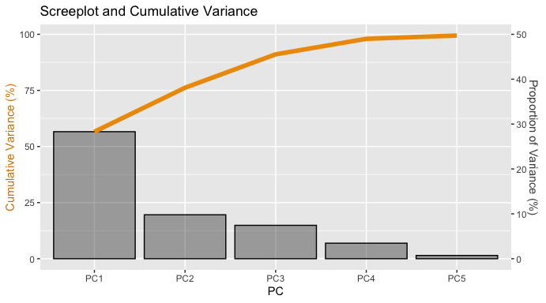

```r
# Perform PCA
a = pcResults(data = BIOspcglyc[,1:8],
              annotation = BIOspcglyc[,-1:-8],
              optns = list(cutoff = 95))

# Call summary plot
a[["plots"]][["combinedScreeCumulative"]]
```

You can display all the principal components up to a number you specify via the optns list as shown below. If not, the previously determined threshold will define the number of PCs viewed.

When plotting the scores, additional arguments can be passed to the optns list. You can set the aesthetics of colour, shape, size and alpha to a variable or you can set it to a simple aesthetic. The axis labels describe the amount of variation accounted for by the repsective PC, relative to the total amount of variation in the data. Only the aesthetics set to a variable will show up in the legend.

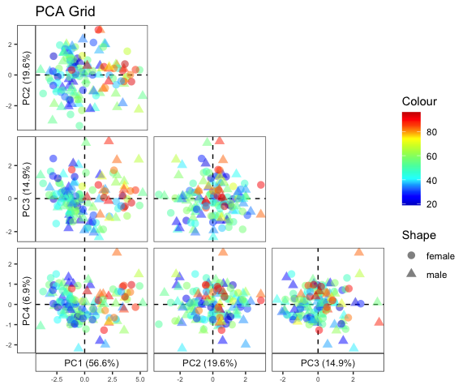

```r
# Plot PCA results: scores of the components up to a threshold or defined number
pcaPlots <- plotScores(model = a,
                       optns = list(thresh = 4,
                                    colourCoding = BIOspcglyc[,"age"],
                                    shapeCoding = BIOspcglyc[,"sex"]))

pcaPlots[["plots"]][["pcaGrid"]]
```

You have the option to add an ellipses. It can be based on colour to help visualise separation, or the entire data to identify outliers. To identify outliers, you may choose Hotelling’s T2, normal or t distribution based ellipses. The default for these options is a 95% confidence interval but you can change this in the optns list using ci as shown in the code below.

You may label all the points outside the ellipses with whichever identifier you select, or via the rownames.

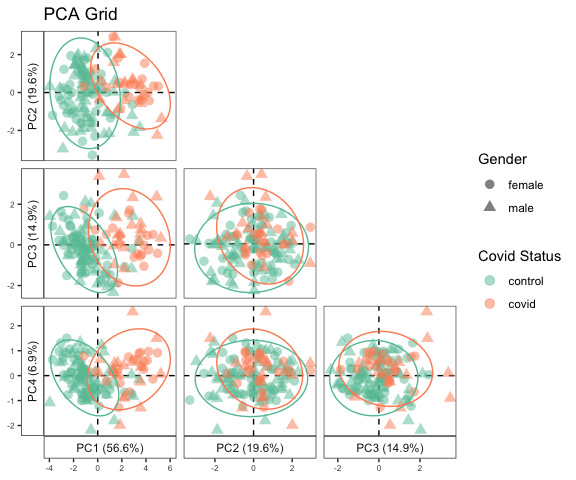

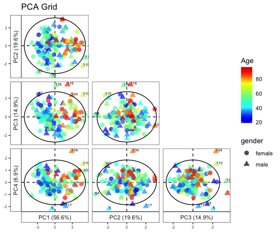

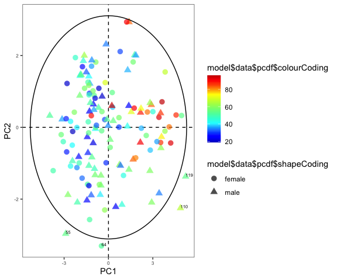

```r
#define ellipse for separation
pcaPlots <- plotScores(model = a,
                       optns = list(colourCoding = BIOspcglyc[,"covid_status"],
                                    colourTitle = "Covid Status",
                                    shapeTitle = "Gender",
                                    shapeCoding = BIOspcglyc[,"sex"],
                                    ellipse = "colour"))
pcaPlots[["plots"]][["pcaGrid"]]

# define ellipse, confidence interval and outlier identification labels
b <- plotScores(model = a,
                optns = list(colourCoding = BIOspcglyc[,"age"],
                             shapeCoding = BIOspcglyc[,"sex"],
                             alphaCoding = 0.7,
                             colourTitle = "Age",
                             shapeTitle = "gender",
                             ellipse = "hotellings",
                             ci = 0.95,
                             outlierLabels = row.names(BIOspcglyc)))
b[["plots"]][["pcaGrid"]]

# to access a single plot
b[["plots"]][["pcaGrid"]][1,1]
```

Any outliers calculated have their associated annotation stored. You can list the entire annotation or a single variable.

```r
# access outlier information for a specific plot (PC1 and PC2 in this case), choosing to display only sampleID:

b[["data"]][["outliers"]][["PC1vPC2"]]$sampleID
```

```
#> [1] "COV02055" "COV02064" "COV02379" "COV02391"
```

To diplay the loadings, see the below code example. You can set the model as the same input as for plotScores or you can supply the results from the plotscores and have the loadings appended to the results.

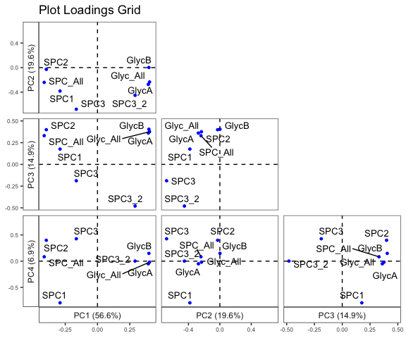

```r
# access outlier information for a specific plot (PC1 and PC2 in this case), choosing to display only sampleID:
c <- plotLoadings(model = b)

c[["plots"]][["plotLoadingGrid"]]
```

## Eruption Plots

Visualise variable importances using Cliff’s delta, loadings and Kruskal Walis rank sum test generated p-value. An alternative offered to the p-value is correlation of the scores and center-scaled data. You can select this in the optns list as shown in the example code below. Since the p-value is a univariate statistic, if wishing to asses your data in a multivariate context, consider using correlation. Additionally, you can select which principal component you wish to use in th loadings and correlation (also seen below). If using the p-value, specify which adjustment method you wish to use in the optns list, for example method = “bonferroni”.

An alternative to Cliff’s Delta offered is fold change.

To be added: changeable thresholds for the x and y axis denotated significance with accompanying colour coding and labelling.

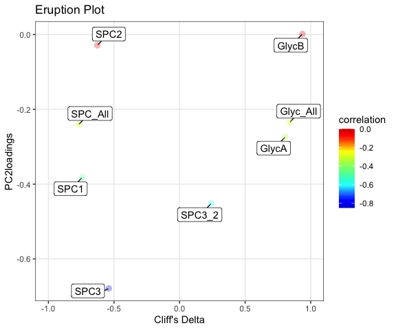

```r
# access outlier information for a specific plot (PC1 and PC2 in this case), choosing to display only sampleID:
d <- eruptionPlot(model = a,
                  factor = BIOspcglyc[,"covid_status"],
                  optns = list(PC = 2,
                               colourCoding = "correlation"))

d[["plots"]][["eruptionPlot"]]
```

To be added: O/PLS/DA, permutation, predict, rgcca, ROC curves, Manhattan, plotloadings for spectra.